- Brian O'Connell
- brr99@pitt.edu

# Exercise-1

```python
import pandas as pd
import numpy as np
import scipy.stats as stats

#statsmodels:
import statsmodels.api as sm
import statsmodels.formula.api as smf
import statsmodels.stats.api as sms
from statsmodels.compat import lzip
from statsmodels.stats.outliers_influence import OLSInfluence
from statsmodels.graphics.regressionplots import plot_leverage_resid2

#scikit-learn:
import sklearn.linear_model as sklm
from sklearn import preprocessing
from sklearn.model_selection import KFold
from sklearn.metrics import mean_squared_error, r2_score
from sklearn.model_selection import train_test_split, cross_validate, cross_val_score
# for KNN with scikit-learn:
from sklearn.neighbors import NearestNeighbors
from sklearn.neighbors import KNeighborsClassifier
from sklearn.neighbors import KNeighborsRegressor
```

```python
# visualization and tuning the aesthetics
import sys
import matplotlib.pylab as plt
import seaborn as sns
%matplotlib inline
sns.set_style("whitegrid")
sns.set_context("notebook", font_scale=1, rc={"lines.linewidth": 2,'font.family': [u'times']})
plt.style.use('seaborn-whitegrid')
plt.rc('text', usetex = False)
plt.rc('font', family = 'serif')
plt.rc('xtick', labelsize = 10)
plt.rc('ytick', labelsize = 10)
plt.rc('font', size = 12)
plt.rc('figure', figsize = (6, 5))
```

```python
#These are utility tools of the DMBA book. Install the "dmba" package first (just one time)

#!pip install dmba
from dmba import regressionSummary, exhaustive_search
from dmba import backward_elimination, forward_selection, stepwise_selection
from dmba import adjusted_r2_score, AIC_score, BIC_score
```

```python
WB = pd.read_csv('WorldBank_Assignment3_Data.csv')
```

```python
WB.describe()
```

|  | 2010 [YR2010] | 2011 [YR2011] | 2012 [YR2012] | 2013 [YR2013] | 2014 [YR2014] | 2015 [YR2015] |
| --- | --- | --- | --- | --- | --- | --- |
| count | 40.000000 | 40.000000 | 40.000000 | 40.000000 | 40.000000 | 40.000000 |
| mean | 82841.609362 | 79419.474037 | 79437.094162 | 78008.568530 | 74043.269281 | 74749.294362 |
| std | 196489.841820 | 188984.495896 | 190855.392296 | 189094.594303 | 179291.857242 | 180090.642929 |
| min | 2.743649 | 2.529051 | 1.525511 | 1.544785 | 1.039374 | 1.085030 |
| 25% | 17.291864 | 18.536404 | 20.949555 | 20.770072 | 22.546798 | 24.357583 |
| 50% | 38.661080 | 38.553073 | 38.333333 | 38.333333 | 38.954671 | 38.322405 |
| 75% | 15081.882913 | 14090.427661 | 12909.189965 | 12945.044969 | 12234.758021 | 11714.174843 |
| max | 881300.000000 | 852550.000000 | 866670.000000 | 883920.000000 | 843660.000000 | 847460.000000 |

```python
WB.info()
```

```
<class 'pandas.core.frame.DataFrame'>
RangeIndex: 45 entries, 0 to 44
Data columns (total 10 columns):
 #   Column         Non-Null Count  Dtype
---  ------         --------------  -----
 0   Country Name   42 non-null     object
 1   Country Code   40 non-null     object
 2   Series Name    40 non-null     object
 3   Series Code    40 non-null     object
 4   2010 [YR2010]  40 non-null     float64
 5   2011 [YR2011]  40 non-null     float64
 6   2012 [YR2012]  40 non-null     float64
 7   2013 [YR2013]  40 non-null     float64
 8   2014 [YR2014]  40 non-null     float64
 9   2015 [YR2015]  40 non-null     float64
dtypes: float64(6), object(4)
memory usage: 3.6+ KB
```

Need to convert to long format

```python
WB_list = WB.columns[5:10]

WB_long = pd.melt(WB, id_vars = ['Country Name'], value_vars = WB_list)
WB_long.columns = ['Country Name','Year','Value']
WB_long
```

[output not shown]

```python
WB.pivot = WB.pivot_table(index='Country Name',
                         columns='Series Name',
                         values='2015 [YR2015]')
WB.pivot
```

| Series Name Country Name | Electricity production from oil, gas and coal sources (% of total) | Electricity production from renewable sources, excluding hydroelectric (% of total) | Proportion of seats held by women in national parliaments (%) | Total greenhouse gas emissions (kt of CO2 equivalent) |
| --- | --- | --- | --- | --- |
| Austria | 22.222042 | 16.493694 | 30.601093 | 75480.0 |
| Belgium | 39.214643 | 20.342785 | 39.333333 | 111520.0 |
| Denmark | 31.899679 | 65.443742 | 37.430168 | 46610.0 |
| France | 6.055788 | 6.196517 | 26.169844 | 430140.0 |
| Germany | 55.063053 | 26.271087 | 36.450079 | 847460.0 |
| Italy | 60.246766 | 22.505878 | 30.952381 | 416150.0 |
| Netherlands | 82.233124 | 12.357591 | 37.333333 | 188330.0 |
| Spain | 44.067144 | 24.820009 | 41.142857 | 325510.0 |
| Sweden | 1.085030 | 16.754050 | 43.553009 | 50050.0 |
| United Kingdom | 53.180856 | 22.970305 | 29.384615 | 497740.0 |

To simplify for this assignment I decided to just use one year to complete the rest of the assignements

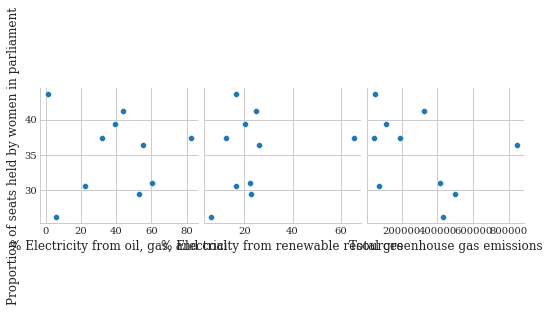

```python
WB.pivot.rename(columns = {'Electricity production from oil, gas and coal sources (% of total)':'% Electricity from oil, gas, and coal','Electricity production from renewable sources, excluding hydroelectric (% of total)':'% Electricity from renewable resources', 'Proportion of seats held by women in national parliaments (%)':'Proportion of seats held by women in parliament', 'Total greenhouse gas emissions (kt of CO2 equivalent)':'Total greenhouse gas emissions'}, inplace = True)

x_var= ['% Electricity from oil, gas, and coal','% Electricity from renewable resources','Total greenhouse gas emissions']
sns.pairplot(data=WB.pivot, y_vars=['Proportion of seats held by women in parliament'], x_vars=x_var)
```

```python
WB.pivot.corr()
```

| Series Name | % Electricity from oil, gas, and coal | % Electricity from renewable resources | Proportion of seats held by women in parliament | Total greenhouse gas emissions |
| --- | --- | --- | --- | --- |
| % Electricity from oil, gas, and coal | 1.000000 | 0.051634 | 0.009815 | 0.346249 |
| % Electricity from renewable resources | 0.051634 | 1.000000 | 0.255133 | -0.174486 |
| Proportion of seats held by women in parliament | 0.009815 | 0.255133 | 1.000000 | -0.353043 |
| Total greenhouse gas emissions | 0.346249 | -0.174486 | -0.353043 | 1.000000 |

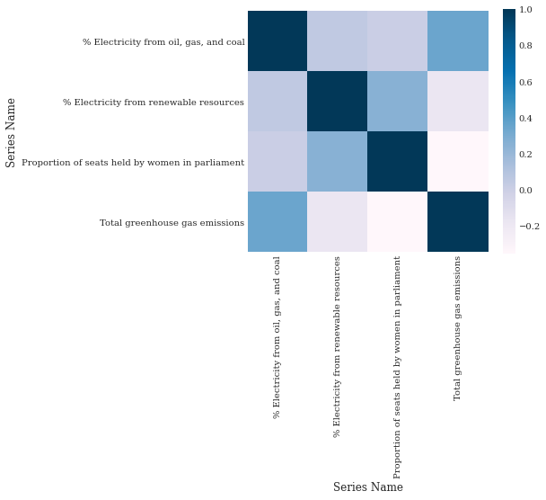

```python
corrmat = WB.pivot.corr()
sns.heatmap(corrmat, square = True, cmap="PuBu")
```

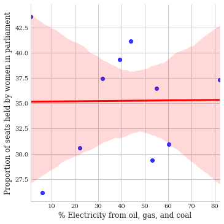

```python
sns.lmplot(x="% Electricity from oil, gas, and coal", y="Proportion of seats held by women in parliament", data=WB.pivot, order=1, ci=95, scatter_kws={'color':'b'}, line_kws={'color':'r'})
```

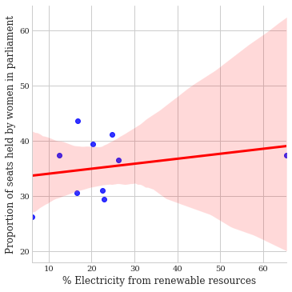

```python
sns.lmplot(x="% Electricity from renewable resources", y="Proportion of seats held by women in parliament", data=WB.pivot, order=1, ci=95, scatter_kws={'color':'b'}, line_kws={'color':'r'})
```

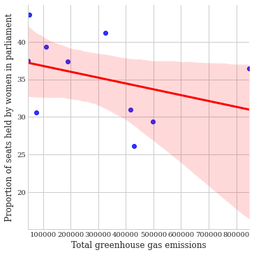

```python
sns.lmplot(x="Total greenhouse gas emissions", y="Proportion of seats held by women in parliament", data=WB.pivot, order=1, ci=95, scatter_kws={'color':'b'}, line_kws={'color':'r'})
```

The exploration of the data is listed above, I am interested in exploring the relationship of the proportion of females in parliment with some environmental factors and what the relationship between these variables is. There seem to be some associations here but it looks like there could be some outliers. Also more data may be needed to really get a picture of this relationship.

# Exercise-2

```python
y=WB.pivot['Proportion of seats held by women in parliament']
X=WB.pivot[['% Electricity from oil, gas, and coal', 'Total greenhouse gas emissions', '% Electricity from renewable resources']]
X=sm.add_constant(X)
model1 = sm.OLS(y, X)
results1 = model1.fit()
results1.summary()
```

OLS Regression Results

| Dep. Variable: | Proportion of seats held by women in parliament | R-squared: | 0.177 |
| --- | --- | --- | --- |
| Model: | OLS | Adj. R-squared: | -0.234 |
| Method: | Least Squares | F-statistic: | 0.4306 |
| Date: | Tue, 26 Oct 2021 | Prob (F-statistic): | 0.739 |
| Time: | 15:55:27 | Log-Likelihood: | -30.013 |
| No. Observations: | 10 | AIC: | 68.03 |
| Df Residuals: | 6 | BIC: | 69.24 |
| Df Model: | 3 |  |  |
| Covariance Type: | nonrobust |  |  |

|  | coef | std err | t | P>\|t\| | [0.025 | 0.975] |
| --- | --- | --- | --- | --- | --- | --- |
| const | 34.9710 | 5.228 | 6.689 | 0.001 | 22.179 | 47.763 |
| % Electricity from oil, gas, and coal | 0.0285 | 0.090 | 0.318 | 0.761 | -0.191 | 0.248 |
| Total greenhouse gas emissions | -8.018e-06 | 8.87e-06 | -0.904 | 0.401 | -2.97e-05 | 1.37e-05 |
| % Electricity from renewable resources | 0.0655 | 0.134 | 0.488 | 0.643 | -0.263 | 0.394 |

| Omnibus: | 2.776 | Durbin-Watson: | 2.166 |
| --- | --- | --- | --- |
| Prob(Omnibus): | 0.250 | Jarque-Bera (JB): | 1.016 |
| Skew: | 0.255 | Prob(JB): | 0.602 |
| Kurtosis: | 1.524 | Cond. No. | 1.02e+06 |

Notes:  
[1] Standard Errors assume that the covariance matrix of the errors is correctly specified.  
[2] The condition number is large, 1.02e+06. This might indicate that there are  
strong multicollinearity or other numerical problems.

```python
predictions1=results1.predict(X)
predictions1.head()
```

```
Country Name
Austria    36.079620
Belgium    36.527436
Denmark    39.791817
France     32.100544
Germany    31.466810
dtype: float64
```

```python
WB.pivot['predicted_prop_of_females']=predictions1
```

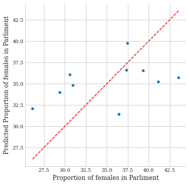

```python
g=sns.relplot(x="Proportion of seats held by women in parliament", y="predicted_prop_of_females", data=WB.pivot) #store the plot in "g"
g.set(xlabel="Proportion of females in Parliment", ylabel="Predicted Proportion of females in Parliment") #set lables for axes
mn = min(WB.pivot['Proportion of seats held by women in parliament'].min(), WB.pivot['Proportion of seats held by women in parliament'].min()) #generate min coordinates for line
mx = max(WB.pivot['Proportion of seats held by women in parliament'].max(), WB.pivot['Proportion of seats held by women in parliament'].max()) #generate max coordinates for line
points = np.linspace(mn, mx, 100) #generate points of the line
plt.plot(points, points, color='r', linestyle='--', linewidth=1.5) #add the line to the plot
plt.show() #show the full plot
#plt.gca().plot(points, points, color='r', linestyle='--', linewidth=1.5) #also works
```

```python
sm.tools.eval_measures.rmse(WB.pivot['Proportion of seats held by women in parliament'], WB.pivot.predicted_prop_of_females, axis=0)
```

```
4.866429210869349
```

Our prediction of the percentage of females in parliment was about 4.86 percent off on average.

```python
regressionSummary(WB.pivot['Proportion of seats held by women in parliament'], WB.pivot.predicted_prop_of_females)
```

```
Regression statistics

                      Mean Error (ME) : -0.0000
       Root Mean Squared Error (RMSE) : 4.8664
            Mean Absolute Error (MAE) : 4.4523
          Mean Percentage Error (MPE) : -2.0000
Mean Absolute Percentage Error (MAPE) : 13.0204
```

#### Regression diagnostics

```python
residuals=results1.resid
```

#### Normality of residuals

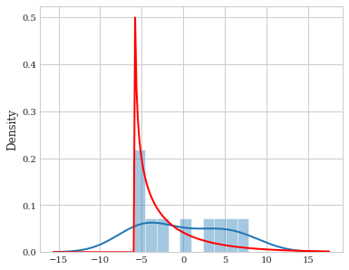

```python
sns.distplot(residuals, bins=10, kde=True, hist=True, fit=stats.gamma, fit_kws={"color":"red"})
```

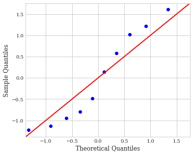

```python
fig=sm.qqplot(residuals, stats.t, fit=True, line='45')
plt.show()
```

#### Heteroskedasticity

```python
name = ['Lagrange multiplier statistic', 'p-value', 'f-value', 'f p-value']
test = sms.het_breuschpagan(results1.resid, results1.model.exog)
lzip(name, test)
```

```
[('Lagrange multiplier statistic', 6.675285338738897),
 ('p-value', 0.08300017871784177),
 ('f-value', 4.015553825727038),
 ('f p-value', 0.06958915345726027)]
```

```python
name = ['F statistic', 'p-value']
test = sms.het_goldfeldquandt(results1.resid, results1.model.exog)
lzip(name, test)
```

```
[('F statistic', 0.8519272872314846), ('p-value', 0.5254779837369544)]
```

#### Multicollinearity

```python
np.linalg.cond(results1.model.exog)
```

```
1015355.2746451249
```

Based on this I feel I must go back and select more dissimilar variables. Some of these are too related to one another.

#### Outliers

```python
test_class = OLSInfluence(results1)
test_class.dfbetas[:5,:]
```

```
array([[-0.49997681,  0.13146242,  0.29283193,  0.20835682],
       [ 0.13453489,  0.05032809, -0.14041063, -0.06062969],
       [ 1.09979152,  0.38403391,  0.57267808, -3.61193863],
       [-0.96444076,  1.00680789, -0.56856914,  0.54641515],
       [-0.75280986, -0.15886052,  1.71689183,  0.46890339]])
```

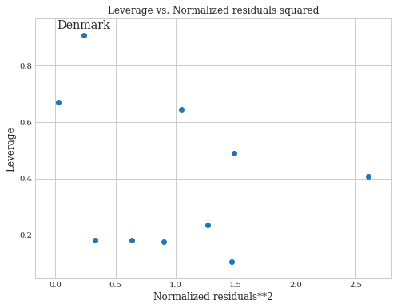

```python
fig, ax = plt.subplots(figsize=(8,6))
fig = plot_leverage_resid2(results1, ax = ax)
```

#### Re-training the model: Exploring alternatives with interactions

```python
WB.pivot['green_renew']=WB.pivot['Total greenhouse gas emissions']*WB.pivot['% Electricity from renewable resources']
```

```python
y=WB.pivot['Proportion of seats held by women in parliament']
X2=WB.pivot[['% Electricity from oil, gas, and coal', 'Total greenhouse gas emissions', '% Electricity from renewable resources', 'green_renew']]
X2=sm.add_constant(X2)
model2 = sm.OLS(y, X2)
results2 = model2.fit()
results2.summary()
```

OLS Regression Results

| Dep. Variable: | Proportion of seats held by women in parliament | R-squared: | 0.485 |
| --- | --- | --- | --- |
| Model: | OLS | Adj. R-squared: | 0.074 |
| Method: | Least Squares | F-statistic: | 1.179 |
| Date: | Tue, 26 Oct 2021 | Prob (F-statistic): | 0.420 |
| Time: | 15:58:26 | Log-Likelihood: | -27.666 |
| No. Observations: | 10 | AIC: | 65.33 |
| Df Residuals: | 5 | BIC: | 66.84 |
| Df Model: | 4 |  |  |
| Covariance Type: | nonrobust |  |  |

|  | coef | std err | t | P>\|t\| | [0.025 | 0.975] |
| --- | --- | --- | --- | --- | --- | --- |
| const | 42.2985 | 6.200 | 6.823 | 0.001 | 26.362 | 58.236 |
| % Electricity from oil, gas, and coal | -0.0180 | 0.082 | -0.219 | 0.835 | -0.229 | 0.193 |
| Total greenhouse gas emissions | -4.735e-05 | 2.4e-05 | -1.974 | 0.105 | -0.000 | 1.43e-05 |
| % Electricity from renewable resources | -0.1099 | 0.154 | -0.713 | 0.508 | -0.506 | 0.286 |
| green_renew | 1.633e-06 | 9.43e-07 | 1.731 | 0.144 | -7.92e-07 | 4.06e-06 |

| Omnibus: | 1.782 | Durbin-Watson: | 1.612 |
| --- | --- | --- | --- |
| Prob(Omnibus): | 0.410 | Jarque-Bera (JB): | 1.077 |
| Skew: | -0.754 | Prob(JB): | 0.584 |
| Kurtosis: | 2.443 | Cond. No. | 3.24e+07 |

Notes:  
[1] Standard Errors assume that the covariance matrix of the errors is correctly specified.  
[2] The condition number is large, 3.24e+07. This might indicate that there are  
strong multicollinearity or other numerical problems.

```python
predictions2=results2.predict(X2)
WB.pivot['predicted_prop_of_females2']=predictions2
```

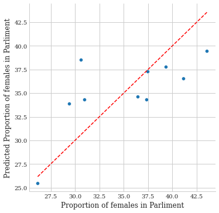

```python
g2=sns.relplot(x="Proportion of seats held by women in parliament", y="predicted_prop_of_females2", data=WB.pivot) #store the plot in "g"
g2.set(xlabel="Proportion of females in Parliment", ylabel="Predicted Proportion of females in Parliment") #set lables for axes
mn2 = min(WB.pivot['Proportion of seats held by women in parliament'].min(), WB.pivot['Proportion of seats held by women in parliament'].min()) #generate min coordinates for line
mx2 = max(WB.pivot['Proportion of seats held by women in parliament'].max(), WB.pivot['Proportion of seats held by women in parliament'].max()) #generate max coordinates for line
points2 = np.linspace(mn2, mx2, 100) #generate points of the line
plt.plot(points2, points2, color='r', linestyle='--', linewidth=1.5) #add the line to the plot
plt.show() #show the full plot
```

```python
sm.tools.eval_measures.rmse(WB.pivot['Proportion of seats held by women in parliament'], WB.pivot.predicted_prop_of_females2, axis=0)
```

```
3.8484133798375826
```

Adding this interaction term helped improve our model quite a bit with a better r^2 value and a lower RMSE value calculated to be 3.8 when before it was 4.866

# Exercise-3

```python
Y = WB.pivot['Proportion of seats held by women in parliament']
X3= WB.pivot.drop(['Proportion of seats held by women in parliament', 'predicted_prop_of_females', 'green_renew', 'predicted_prop_of_females2'], axis=1).values
```

```python
X3[:5]
```

```
array([[2.22220423e+01, 1.64936936e+01, 7.54800000e+04],
       [3.92146431e+01, 2.03427848e+01, 1.11520000e+05],
       [3.18996787e+01, 6.54437420e+01, 4.66100000e+04],
       [6.05578764e+00, 6.19651673e+00, 4.30140000e+05],
       [5.50630532e+01, 2.62710873e+01, 8.47460000e+05]])
```

```python
WB.pivot.head()
```

| Series Name Country Name | % Electricity from oil, gas, and coal | % Electricity from renewable resources | Proportion of seats held by women in parliament | Total greenhouse gas emissions | predicted_prop_of_females | green_renew | predicted_prop_of_females2 |
| --- | --- | --- | --- | --- | --- | --- | --- |
| Austria | 22.222042 | 16.493694 | 30.601093 | 75480.0 | 36.079620 | 1.244944e+06 | 38.544311 |
| Belgium | 39.214643 | 20.342785 | 39.333333 | 111520.0 | 36.527436 | 2.268627e+06 | 37.780037 |
| Denmark | 31.899679 | 65.443742 | 37.430168 | 46610.0 | 39.791817 | 3.050333e+06 | 37.305354 |
| France | 6.055788 | 6.196517 | 26.169844 | 430140.0 | 32.100544 | 2.665370e+06 | 25.494499 |
| Germany | 55.063053 | 26.271087 | 36.450079 | 847460.0 | 31.466810 | 2.226370e+07 | 34.646555 |

```python
#model specification
femalereg=sklm.LinearRegression()
femalereg.fit(X3, Y)
```

```
LinearRegression()
```

```python
# look into the regression results, if desired
print('Intercept:', femalereg.intercept_)
print('% Electricity from oil, gas, and coal:', femalereg.coef_[0])
print('% Electricity from renewable resources:', femalereg.coef_[1])
print('Total greenhouse gas emissions:', femalereg.coef_[2])
```

```
Intercept: 34.97104006291263
% Electricity from oil, gas, and coal: 0.028530259332935577
% Electricity from renewable resources: 0.06546688937919136
Total greenhouse gas emissions: -8.018170939788627e-06
```

```python
# Fourth, get the predicted values and evaluate the training:
sk_predictions=femalereg.predict(X3) # predictions for training set
```

```python
np.sqrt(mean_squared_error(Y, sk_predictions))
```

```
4.8664292108693505
```

### K-fold Cross Validation

```python
X_train, X_test, Y_train, Y_test = train_test_split(X3, Y, test_size=0.25, random_state=23)
print(X_train.shape, Y_train.shape)
print(X_test.shape, Y_test.shape)
```

```
(7, 3) (7,)
(3, 3) (3,)
```

```python
#training model
femalereg2=sklm.LinearRegression()
femalereg2.fit(X_train, Y_train)
```

```
LinearRegression()
```

```python
#3-fold cross validation
cvparam = KFold(3)
scores_mse_lm =  cross_validate(femalereg2, X_train, Y_train, cv=cvparam, scoring='neg_mean_squared_error')
```

```python
scores_mse_lm
```

```
{'fit_time': array([0.00195909, 0.00097656, 0.00195289]),
 'score_time': array([0.        , 0.0009768 , 0.00097704]),
 'test_score': array([-768.73937345,  -12.95826873, -997.79811685])}
```

```python
scores_mse_lm['test_score']
```

```
array([-768.73937345,  -12.95826873, -997.79811685])
```

```python
np.sqrt(scores_mse_lm['test_score'].mean()*-1)
```

```
24.354984151347946
```

```python
lm_predictions_tt=femalereg2.predict(X_test) #use test sample and coefficients derived from trained model
np.sqrt(np.square(lm_predictions_tt-Y_test).mean()) #compare predictions with actual values in test sample
```

```
13.068515971637497
```

```python
X4 = WB.pivot[['% Electricity from oil, gas, and coal', 'Total greenhouse gas emissions', '% Electricity from renewable resources', 'green_renew']].values
X_train2, X_test2, Y_train2, Y_test2 = train_test_split(X4, Y, test_size=0.25, random_state=7)
```

```python
#training model
femalereg3=sklm.LinearRegression()
femalereg3.fit(X_train2, Y_train2)
```

```
LinearRegression()
```

```python
#3-fold cross validation
cvparam = KFold(3)
scores_mse_lm2 =  cross_validate(femalereg3, X_train2, Y_train2, cv=cvparam, scoring='neg_mean_squared_error')
```

```python
np.sqrt(scores_mse_lm2['test_score'].mean()*-1)
```

```
30.948500411308192
```

```python
lm_predictions_tt2=femalereg3.predict(X_test2) #use test sample and coefficients derived from trained model
np.sqrt(np.square(lm_predictions_tt2-Y_test2).mean()) #compare predictions with actual values in test sample
```

```
7.096705365333258
```

# Exercise-4

```python
WB2 = pd.read_csv('WorldBank_Assignment3_Data.csv')
WB.pivot2 = WB2.pivot_table(index='Country Name',
                         columns='Series Name',
                         values='2015 [YR2015]')
WB.pivot2.rename(columns = {'Electricity production from oil, gas and coal sources (% of total)':'% Electricity from oil, gas, and coal','Electricity production from renewable sources, excluding hydroelectric (% of total)':'% Electricity from renewable resources', 'Proportion of seats held by women in national parliaments (%)':'Proportion of seats held by women in parliament', 'Total greenhouse gas emissions (kt of CO2 equivalent)':'Total greenhouse gas emissions'}, inplace = True)
WB.pivot2
```

| Series Name Country Name | % Electricity from oil, gas, and coal | % Electricity from renewable resources | Proportion of seats held by women in parliament | Total greenhouse gas emissions |
| --- | --- | --- | --- | --- |
| Austria | 22.222042 | 16.493694 | 30.601093 | 75480.0 |
| Belgium | 39.214643 | 20.342785 | 39.333333 | 111520.0 |
| Denmark | 31.899679 | 65.443742 | 37.430168 | 46610.0 |
| France | 6.055788 | 6.196517 | 26.169844 | 430140.0 |
| Germany | 55.063053 | 26.271087 | 36.450079 | 847460.0 |
| Italy | 60.246766 | 22.505878 | 30.952381 | 416150.0 |
| Netherlands | 82.233124 | 12.357591 | 37.333333 | 188330.0 |
| Spain | 44.067144 | 24.820009 | 41.142857 | 325510.0 |
| Sweden | 1.085030 | 16.754050 | 43.553009 | 50050.0 |
| United Kingdom | 53.180856 | 22.970305 | 29.384615 | 497740.0 |

```python
# First, scale the predictors:
Xp=preprocessing.scale(WB.pivot2[['% Electricity from oil, gas, and coal', '% Electricity from renewable resources', 'Total greenhouse gas emissions']]).astype('float64')
Yp=preprocessing.scale(WB.pivot2['Proportion of seats held by women in parliament']).astype('float64')
# not scaling the dependent variable will help comparison with the earlier models
Ypns=(WB.pivot2['Proportion of seats held by women in parliament']).astype('float64')
```

```python
# Set aside a portion (e.g., 25%) of data for out-of-training-sample testing.

# to use the scaled Sales DV:
X3p_train, X3p_test, Y3p_train, Y3p_test = train_test_split(Xp, Yp, \
                                                            test_size=0.25, random_state=7)

#using the unscaled Sales DV
X3p_train, X3p_test, Y3pns_train, Y3pns_test = train_test_split(Xp, Ypns, \
                                                            test_size=0.25, random_state=7)
print("Scaled version:")
print(X3p_train.shape, Y3p_train.shape)
print(X3p_test.shape, Y3p_test.shape)
print("Not scaled version:")
print(X3p_train.shape, Y3pns_train.shape)
print(X3p_test.shape, Y3pns_test.shape)
```

```
Scaled version:
(7, 3) (7,)
(3, 3) (3,)
Not scaled version:
(7, 3) (7,)
(3, 3) (3,)
```

```python
# Define the KNN model parameters
# use 4 nearest neighbors weighted uniformly
knn_rcv = KNeighborsRegressor(n_neighbors=4, weights='uniform')
knn_rcv_ns = KNeighborsRegressor(n_neighbors=4, weights='uniform')
```

```python
# fit the KNN model using training sample
knn_rcv.fit(X3p_train, Y3p_train)
knn_rcv_ns.fit(X3p_train, Y3pns_train)
```

```
KNeighborsRegressor(n_neighbors=4)
```

```python
# how does the model perform in training?
#get the predictions using training data
knn_prediction_reg=knn_rcv.predict(X3p_train)
knn_prediction_reg_ns=knn_rcv_ns.predict(X3p_train)
```

```python
np.sqrt(np.square(Y3p_train-knn_prediction_reg).mean())
```

```
0.8603731961320107
```

```python
np.sqrt(np.square(Y3pns_train-knn_prediction_reg_ns).mean())
```

```
4.615679956063458
```

```python
import statsmodels.api as sm
sm.tools.eval_measures.rmse(Y3pns_train, knn_prediction_reg_ns, axis=0)
```

```
4.615679956063458
```

```python
regressionSummary(Y3pns_train, knn_prediction_reg_ns)
```

```
Regression statistics

                      Mean Error (ME) : -0.5495
       Root Mean Squared Error (RMSE) : 4.6157
            Mean Absolute Error (MAE) : 3.7451
          Mean Percentage Error (MPE) : -3.6703
Mean Absolute Percentage Error (MAPE) : 11.8809
```

```python
regressionSummary(Y3p_train, knn_prediction_reg)
```

```
Regression statistics

                      Mean Error (ME) : -0.1024
       Root Mean Squared Error (RMSE) : 0.8604
            Mean Absolute Error (MAE) : 0.6981
          Mean Percentage Error (MPE) : 94.0431
Mean Absolute Percentage Error (MAPE) : 94.0431
```

```python
WB.pivot2['Proportion of seats held by women in parliament'].describe()
```

```
count    10.000000
mean     35.235071
std       5.654934
min      26.169844
25%      30.688915
50%      36.891706
75%      38.857542
max      43.553009
Name: Proportion of seats held by women in parliament, dtype: float64
```

```python
#to rescale the predicted values, we need to first fit the original scaler:
data = WB.pivot2['Proportion of seats held by women in parliament'].values
scaler = preprocessing.StandardScaler()
scaler.fit(data.reshape(-1, 1)) #reshaping is needed for 1-dimensional arrays
scaled = scaler.transform(data.reshape(-1, 1))
# for inverse transformation
inversedpredictions = scaler.inverse_transform(knn_prediction_reg)
```

```python
regressionSummary(Y3p_train,inversedpredictions)
```

```
Regression statistics

                      Mean Error (ME) : -35.8541
       Root Mean Squared Error (RMSE) : 35.8776
            Mean Absolute Error (MAE) : 35.8541
          Mean Percentage Error (MPE) : -5028.1836
Mean Absolute Percentage Error (MAPE) : 6618.6548
```

```python
# how does the model perform when there is variation on different training samples?
cvparam = KFold(3)
scores_mse_knn =  cross_validate(knn_rcv_ns, X3p_train, Y3pns_train, \
                                 cv=cvparam, scoring='neg_mean_squared_error') #3-fold
```

```python
# how does the model perform when there is variation on different training samples?
scores_mse_knn['test_score']
```

```
array([-18.60402614, -59.92470109,  -8.51274318])
```

```python
np.sqrt(scores_mse_knn['test_score'].mean()*-1) #Multiplying by -1 to remove negativity in MSE
```

```
5.386448131202685
```

```python
# How does the trained model do for the testing sample?
knn_prediction_reg_tt=knn_rcv_ns.predict(X3p_test) #get the predictions using test data
```

```python
#average error of prediction in training data.
np.sqrt(np.square(knn_prediction_reg_tt-Y3pns_test).mean())
```

```
6.755142823908636
```

```python
regressionSummary(Y3pns_test,knn_prediction_reg_tt)
```

```
Regression statistics

                      Mean Error (ME) : 0.0975
       Root Mean Squared Error (RMSE) : 6.7551
            Mean Absolute Error (MAE) : 6.2660
          Mean Percentage Error (MPE) : -2.7010
Mean Absolute Percentage Error (MAPE) : 17.3121
```